# Project: Communicate data findings(Ford GoBike System Data)

## Made by : Yasmine Hussein

### Date : Mar 2021

- Introduction
- Data Wrangling
- Exploratory Data Analysis
- Conclusions

## Introduction

> This data set includes information about individual rides made in a bike-sharing system covering the greater San Francisco Bay area.

> **Questions to be answered**:
> - What is the number of custmers and subscribers?
> - Maximum duration for each user type
> - What is the most popular start station?
> - Which gender is most riding bikes?
> - weekly trips
> - User type split for GoBike sharing system
> - Weekly usage of the bike share system per user type
> - Gender population for user type
> - Hourly usage during the weekday for customers and subscribers

```python
# Import statements for all of the packages that planned to use.
import numpy as np
import pandas as pd
import matplotlib.pyplot as plt
import seaborn as sb

%matplotlib inline
```

## Gathering Data

### Ford GoBike System Data

```python
# loading data in dataframe

df = pd.read_csv('fordgobike.csv')

# summary of the data

print(df.shape)
print(df.info())
df.head()
```

```
(183412, 16)
<class 'pandas.core.frame.DataFrame'>
RangeIndex: 183412 entries, 0 to 183411
Data columns (total 16 columns):
 #   Column                   Non-Null Count   Dtype
---  ------                   --------------   -----
 0   duration_sec             183412 non-null  int64
 1   start_time               183412 non-null  object
 2   end_time                 183412 non-null  object
 3   start_station_id         183215 non-null  float64
 4   start_station_name       183215 non-null  object
 5   start_station_latitude   183412 non-null  float64
 6   start_station_longitude  183412 non-null  float64
 7   end_station_id           183215 non-null  float64
 8   end_station_name         183215 non-null  object
 9   end_station_latitude     183412 non-null  float64
 10  end_station_longitude    183412 non-null  float64
 11  bike_id                  183412 non-null  int64
 12  user_type                183412 non-null  object
 13  member_birth_year        175147 non-null  float64
 14  member_gender            175147 non-null  object
 15  bike_share_for_all_trip  183412 non-null  object
dtypes: float64(7), int64(2), object(7)
memory usage: 22.4+ MB
None
```

|  | duration_sec | start_time | end_time | start_station_id | start_station_name | start_station_latitude | start_station_longitude | end_station_id | end_station_name | end_station_latitude | end_station_longitude | bike_id | user_type | member_birth_year | member_gender | bike_share_for_all_trip |
| --- | --- | --- | --- | --- | --- | --- | --- | --- | --- | --- | --- | --- | --- | --- | --- | --- |
| 0 | 52185 | 2019-02-28 17:32:10.1450 | 2019-03-01 08:01:55.9750 | 21.0 | Montgomery St BART Station (Market St at 2nd St) | 37.789625 | -122.400811 | 13.0 | Commercial St at Montgomery St | 37.794231 | -122.402923 | 4902 | Customer | 1984.0 | Male | No |
| 1 | 42521 | 2019-02-28 18:53:21.7890 | 2019-03-01 06:42:03.0560 | 23.0 | The Embarcadero at Steuart St | 37.791464 | -122.391034 | 81.0 | Berry St at 4th St | 37.775880 | -122.393170 | 2535 | Customer | NaN | NaN | No |
| 2 | 61854 | 2019-02-28 12:13:13.2180 | 2019-03-01 05:24:08.1460 | 86.0 | Market St at Dolores St | 37.769305 | -122.426826 | 3.0 | Powell St BART Station (Market St at 4th St) | 37.786375 | -122.404904 | 5905 | Customer | 1972.0 | Male | No |
| 3 | 36490 | 2019-02-28 17:54:26.0100 | 2019-03-01 04:02:36.8420 | 375.0 | Grove St at Masonic Ave | 37.774836 | -122.446546 | 70.0 | Central Ave at Fell St | 37.773311 | -122.444293 | 6638 | Subscriber | 1989.0 | Other | No |
| 4 | 1585 | 2019-02-28 23:54:18.5490 | 2019-03-01 00:20:44.0740 | 7.0 | Frank H Ogawa Plaza | 37.804562 | -122.271738 | 222.0 | 10th Ave at E 15th St | 37.792714 | -122.248780 | 4898 | Subscriber | 1974.0 | Male | Yes |

## Data Wrangling

### General Properties

```python
# check for duplicates

df.bike_id.duplicated().sum()
```

```
178766
```

```python
# drop duplicates

df.bike_id.drop_duplicates(inplace= True)
# check again
df.bike_id.duplicated().sum()
```

```
0
```

```python
# check for null values

df.isnull().sum()
```

```
duration_sec                  0
start_time                    0
end_time                      0
start_station_id            197
start_station_name          197
start_station_latitude        0
start_station_longitude       0
end_station_id              197
end_station_name            197
end_station_latitude          0
end_station_longitude         0
bike_id                       0
user_type                     0
member_birth_year          8265
member_gender              8265
bike_share_for_all_trip       0
dtype: int64
```

```python
# drop NAN values

df.dropna(inplace= True)

# check again
df.isnull().sum()
```

```
duration_sec               0
start_time                 0
end_time                   0
start_station_id           0
start_station_name         0
start_station_latitude     0
start_station_longitude    0
end_station_id             0
end_station_name           0
end_station_latitude       0
end_station_longitude      0
bike_id                    0
user_type                  0
member_birth_year          0
member_gender              0
bike_share_for_all_trip    0
dtype: int64
```

```python
# drop unneccessary columns

print(df.columns)

df.drop(columns=['start_station_latitude','start_station_longitude', 'end_station_latitude', 'end_station_longitude'], inplace=True)

df.info()
```

```
Index(['duration_sec', 'start_time', 'end_time', 'start_station_id',
       'start_station_name', 'start_station_latitude',
       'start_station_longitude', 'end_station_id', 'end_station_name',
       'end_station_latitude', 'end_station_longitude', 'bike_id', 'user_type',
       'member_birth_year', 'member_gender', 'bike_share_for_all_trip'],
      dtype='object')
<class 'pandas.core.frame.DataFrame'>
Int64Index: 174952 entries, 0 to 183411
Data columns (total 12 columns):
 #   Column                   Non-Null Count   Dtype
---  ------                   --------------   -----
 0   duration_sec             174952 non-null  int64
 1   start_time               174952 non-null  object
 2   end_time                 174952 non-null  object
 3   start_station_id         174952 non-null  float64
 4   start_station_name       174952 non-null  object
 5   end_station_id           174952 non-null  float64
 6   end_station_name         174952 non-null  object
 7   bike_id                  174952 non-null  int64
 8   user_type                174952 non-null  object
 9   member_birth_year        174952 non-null  float64
 10  member_gender            174952 non-null  object
 11  bike_share_for_all_trip  174952 non-null  object
dtypes: float64(3), int64(2), object(7)
memory usage: 17.4+ MB
```

```python
# fixing date-time variables

df.start_time = pd.to_datetime(df.start_time)
df.end_time = pd.to_datetime(df.end_time)
df.member_birth_year= df.member_birth_year.astype('int64')
df.start_station_id= df.start_station_id.astype('int64')
df.end_station_id= df.end_station_id.astype('int64')

df.info()
```

```
<class 'pandas.core.frame.DataFrame'>
Int64Index: 174952 entries, 0 to 183411
Data columns (total 12 columns):
 #   Column                   Non-Null Count   Dtype
---  ------                   --------------   -----
 0   duration_sec             174952 non-null  int64
 1   start_time               174952 non-null  datetime64[ns]
 2   end_time                 174952 non-null  datetime64[ns]
 3   start_station_id         174952 non-null  int64
 4   start_station_name       174952 non-null  object
 5   end_station_id           174952 non-null  int64
 6   end_station_name         174952 non-null  object
 7   bike_id                  174952 non-null  int64
 8   user_type                174952 non-null  object
 9   member_birth_year        174952 non-null  int64
 10  member_gender            174952 non-null  object
 11  bike_share_for_all_trip  174952 non-null  object
dtypes: datetime64[ns](2), int64(5), object(5)
memory usage: 17.4+ MB
```

```python
# adding month column

df['weekday']= df.start_time.dt.day_name()
df['hour']= df.start_time.dt.hour
```

```python
df.head()
```

|  | duration_sec | start_time | end_time | start_station_id | start_station_name | end_station_id | end_station_name | bike_id | user_type | member_birth_year | member_gender | bike_share_for_all_trip | weekday | hour |
| --- | --- | --- | --- | --- | --- | --- | --- | --- | --- | --- | --- | --- | --- | --- |
| 0 | 52185 | 2019-02-28 17:32:10.145 | 2019-03-01 08:01:55.975 | 21 | Montgomery St BART Station (Market St at 2nd St) | 13 | Commercial St at Montgomery St | 4902 | Customer | 1984 | Male | No | Thursday | 17 |
| 2 | 61854 | 2019-02-28 12:13:13.218 | 2019-03-01 05:24:08.146 | 86 | Market St at Dolores St | 3 | Powell St BART Station (Market St at 4th St) | 5905 | Customer | 1972 | Male | No | Thursday | 12 |
| 3 | 36490 | 2019-02-28 17:54:26.010 | 2019-03-01 04:02:36.842 | 375 | Grove St at Masonic Ave | 70 | Central Ave at Fell St | 6638 | Subscriber | 1989 | Other | No | Thursday | 17 |
| 4 | 1585 | 2019-02-28 23:54:18.549 | 2019-03-01 00:20:44.074 | 7 | Frank H Ogawa Plaza | 222 | 10th Ave at E 15th St | 4898 | Subscriber | 1974 | Male | Yes | Thursday | 23 |
| 5 | 1793 | 2019-02-28 23:49:58.632 | 2019-03-01 00:19:51.760 | 93 | 4th St at Mission Bay Blvd S | 323 | Broadway at Kearny | 5200 | Subscriber | 1959 | Male | No | Thursday | 23 |

## Exploratory Data Analysis

### What is the number of custmers and subscribers?

```python
df.user_type.value_counts()
```

```
Subscriber    158386
Customer       16566
Name: user_type, dtype: int64
```

### Maximum duration for each user type

```python
df.groupby('user_type')['duration_sec'].max()
```

```
user_type
Customer      83519
Subscriber    84548
Name: duration_sec, dtype: int64
```

### What is the most popular start station?

```python
df.start_station_name.mode()
```

```
0    Market St at 10th St
dtype: object
```

### Which gender is most riding bikes?

```python
df.member_gender.mode()
```

```
0    Male
dtype: object
```

## Univariate Exploration

#### weekly trips

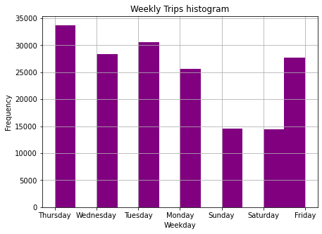

```python
df.weekday.hist(color='purple', bins=12, figsize=(7,5));
plt.title("Weekly Trips histogram")
plt.xlabel('Weekday')
plt.ylabel('Frequency');
```

The bike share system is mainly used during weekdays, with Tuesday - Thursday as the most popular days for bike rides.

#### hourly usege of the bike sharing system

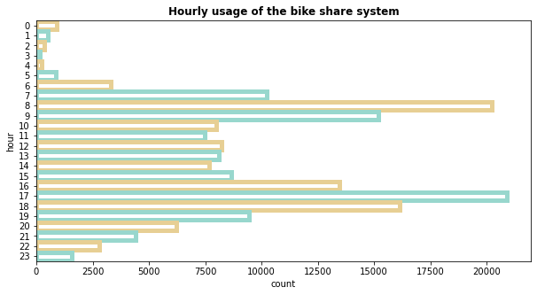

```python
plt.figure(figsize = [10, 5])
g = sb.countplot(data=df, y='hour', facecolor=(0, 0, 0, 0),
                   linewidth=5,
                   edgecolor=sb.color_palette("BrBG", 2))
plt.title('Hourly usage of the bike share system', fontsize=12, fontweight='bold');
```

The hourly distribution is bimodal, the system is used mainly around 7-8am and 5-6pm when people get to and gat back from work.

#### Frequent birth year users

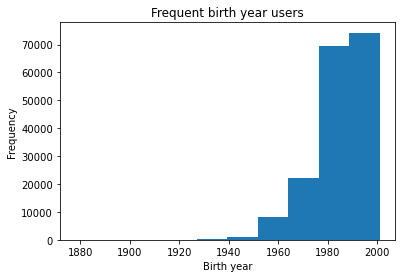

```python
# retrieving member_birth_year data and plot it
df.member_birth_year.plot(kind="hist")

plt.title("Frequent birth year users", fontsize="12")
plt.xlabel('Birth year')
plt.ylabel('Frequency');
```

Graph shows that most member are with birth year between 1980 - 2000

## Bivariate Exploration

#### Weekly usage of the bike share system per user type

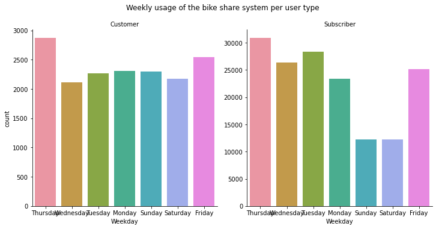

```python
# weekday usege of the bike sharing system per user type
plt.figure(figsize = [15, 5])
g = sb.catplot(data=df, x='weekday', col="user_type", kind='count', sharey = False,
            color = sb.set_palette("mako"))
g.set_xlabels("Weekday")
g.set_titles("{col_name}")
g.fig.suptitle('Weekly usage of the bike share system per user type', y=1.05);
```

#### hourly usage of the bike sharing system per user type

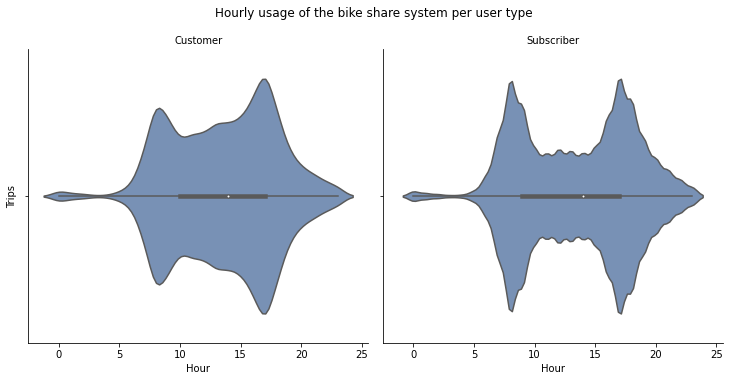

```python
# plotting hours versus count trips per user type

g = sb.catplot(data=df, x='hour', col="user_type", kind="violin",
            color = sb.set_palette("vlag"))
g.set_xlabels("Hour")
g.set_ylabels("Trips")
g.set_titles("{col_name}")
g.fig.suptitle('Hourly usage of the bike share system per user type', y=1.05);
```

Customers use bikes mainly between 8 am - 7 pm, reaching the renting peak around 5pm. Subscribers on the other side use the system at around 8-9am and 5-6pm equally which shows they use it to go and come back from work.

#### User type for GoBike sharing system

```python
# calculating propotion for each user type
customer = df.query('user_type == "Customer"')['bike_id'].count()
subscriber = df.query('user_type == "Subscriber"')['bike_id'].count()

customer_prop = customer / df['bike_id'].count()
subscriber_prop = subscriber / df['bike_id'].count()
```

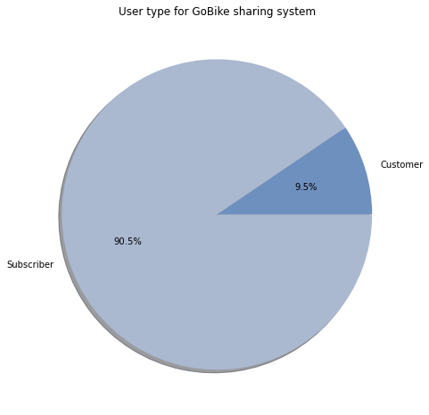

```python
#plotting the data
plt.figure(figsize = [8, 8])

plt.pie([customer_prop, subscriber_prop], labels=['Customer', 'Subscriber'], colors= sb.color_palette(),
        autopct='%1.1f%%', shadow=True)

plt.title('User type for GoBike sharing system');
```

The bike sharing system is mainly used by subscribers (90%) than ocassional riders (10%)

#### The trip duration varies between customers and subscribers

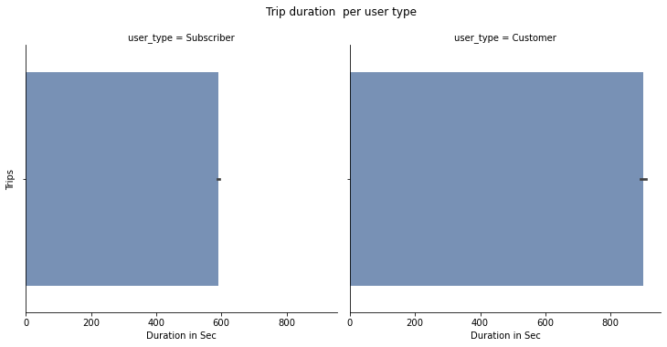

```python
# plotting trip duration per user type
data = df.query('duration_sec < 3600')
g = sb.FacetGrid(data, col="user_type", margin_titles=True, height=5)
g.map(sb.barplot, "duration_sec", color=sb.set_palette("muted"), order=data.user_type.value_counts().index)
g.set_axis_labels("Duration in Sec", "Trips")
g.set_titles('{col_name}')
g.fig.suptitle('Trip duration  per user type', y=1.05);
```

Graphs shows that Subscribers has a shorter duration than Customers

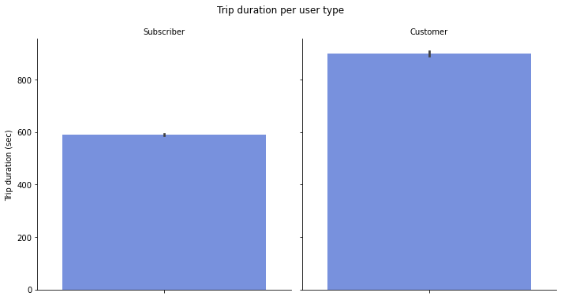

```python
# plotting duration per each user type
data = df.query('duration_sec < 3600')
g = sb.catplot(data=data, y='duration_sec', col="user_type", kind='bar',
            color = sb.set_palette("coolwarm"), order=df.user_type.value_counts().index)
g.set_titles(col_template = '{col_name}')
g.set_axis_labels("", "Trip duration (sec)")
g.fig.suptitle('Trip duration per user type', y=1.05);
```

Same result for count bars!. This can probably be explained by the fact that subscribers are mainly commuters who take short trips to work/school rather than longer trips around the Bay Area.

## Multivariate Exploration

#### Member birth year duration for user type in bike sharing system

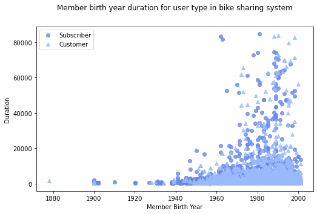

```python
# plotting count chart for member gender

plt.figure(figsize = [18, 5])
plt.subplot(1, 2, 1)
tmarker= [['Subscriber', 'o'], ['Customer','^']]
for ttype, marker in tmarker:
         user_data = df.loc[df["user_type"]== ttype]
         g = sb.regplot(data=user_data, x="member_birth_year", y="duration_sec", x_jitter=0.04, fit_reg= False,
                         marker= marker)
g.set_xlabel('Member Birth Year')
g.set_title('Member birth year duration for user type in bike sharing system', y=1.08)
g.legend(['Subscriber', 'Customer'])
g.set_ylabel('Duration');
```

Graph shows that subscribers and customer user types are both almost have the same duration distribution for all birth years. Also we have an outlier record for 1880 birth year!

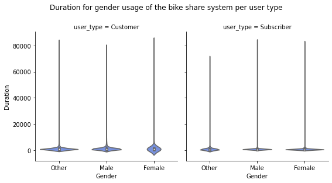

```python
# weekday usage of the bike sharing system per user type and gender
plt.figure(figsize = [18, 5])
g = sb.FacetGrid(data = df, col = 'user_type', height = 4)
g.map(sb.violinplot, 'member_gender', 'duration_sec')
g.set_axis_labels("Gender", "Duration")
g.fig.suptitle('Duration for gender usage of the bike share system per user type', y=1.08);
```

#### hourly usage of the bike sharing system per user type and gender

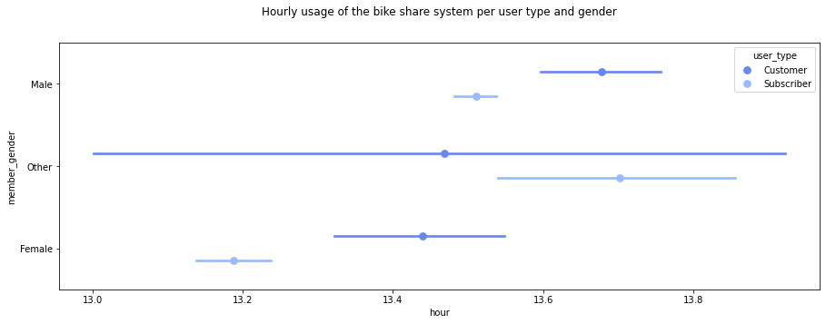

```python
# hourly usege of the bike sharing system per user type and gender
plt.figure(figsize = [15, 5])
g = sb.pointplot(data = df, y = 'member_gender', x = 'hour', hue = 'user_type',
                  dodge = 0.3, linestyles = "")
plt.title('Hourly usage of the bike share system per user type and gender', y=1.09);
```

Chart showing that male is using shorter range with higher hours of bike sharing system, while females use wider range with shorter hours.

#### The duration distribution per user type and gender

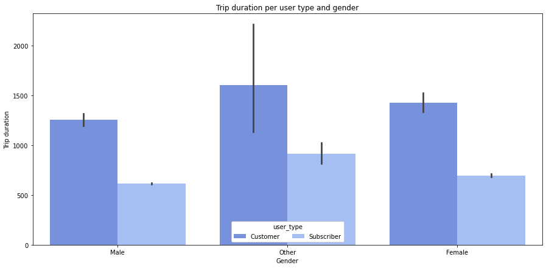

```python
#plotting duration for user type with each gender

plt.figure(figsize = [15, 7])
g= sb.barplot(data = df, x = 'member_gender', y = 'duration_sec', hue = 'user_type')
g.legend(loc = 8, ncol = 3, framealpha = 1, title = 'user_type')

plt.ylabel("Trip duration")
plt.xlabel("Gender")
plt.title('Trip duration per user type and gender');
```

As shown in figure, Females take longer trips than males and other is the longest trips specially for customers. The difference is more visible for customers than for subscribers.

#### Hourly usage during the weekday for customers and subscribers

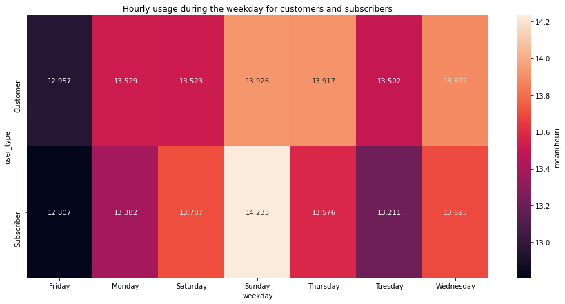

```python
#plotting hourly usage user type within week

plt.figure(figsize = [15, 7])

cat_means = df.groupby(['weekday', 'user_type']).mean()['hour']
cat_means = cat_means.reset_index(name = 'bike_id')
cat_means = cat_means.pivot(index = 'user_type', columns = 'weekday',
                            values = 'bike_id')
sb.heatmap(cat_means, annot = True, fmt = '.3f',
           cbar_kws = {'label' : 'mean(hour)'})
plt.title('Hourly usage during the weekday for customers and subscribers');
```

>